# FX Live - Análisis Técnico y de Riesgo - Costa Rica

# 📊 Resumen Ejecutivo

**Fecha del Análisis:** 21 de November, 2025

**Precio Actual:** 495.92 (↘️ 0.00% vs día anterior)

**Tendencia General:** Apreciación (Largo Plazo)

**Bandas de Normalidad indican:** Sobreventa

**Percentil Historico:** 0.1/100

🚨 Precio fuera de banda inferior (20 períodos) - Posible sobreapreciación

🚨 Precio fuera de banda inferior (50 períodos) - Posible sobreapreciación

# 📈 Posición Actual

| Métrica | Valor |
| --- | --- |
| Precio | 495.92 |
| Cambio respecto al día anterior (%) | 0.00% |
| Cambio Semanal (%) | -0.34% |
| Cambio Anual (%) | -2.55% |
| Volatilidad (20d) | ₡ 15.37 |
| Tendencia Corto | Apreciación |
| Tendencia Medio | Apreciación |
| Tendencia Largo | Apreciación |

# 📊 Análisis Técnico

## Evolución del Precio

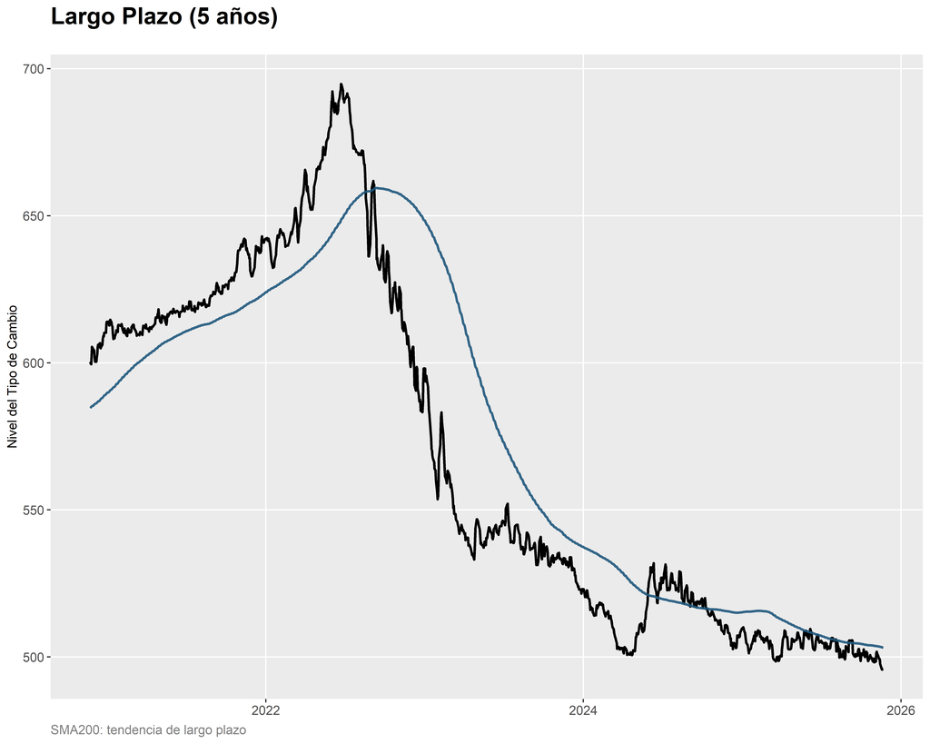

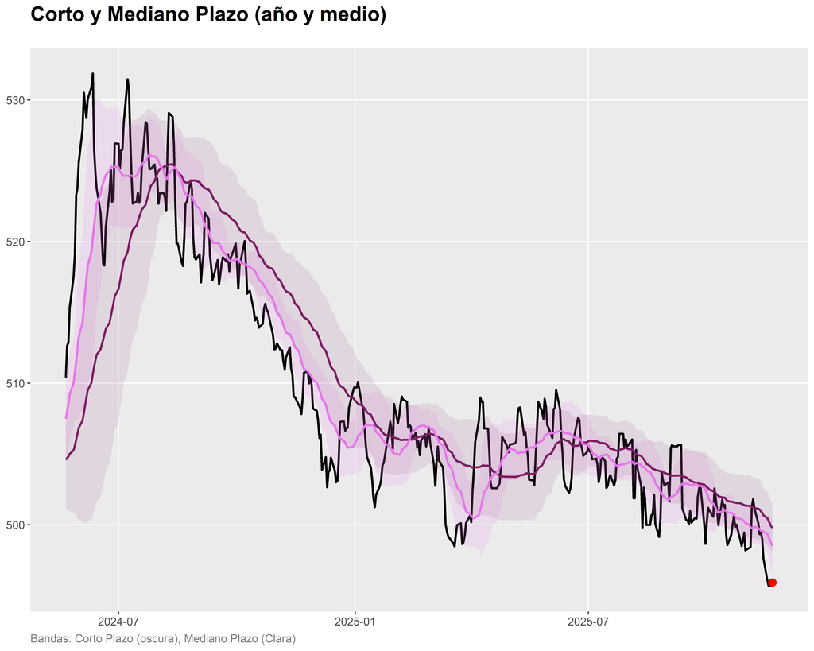

## Análisis de Volatilidad

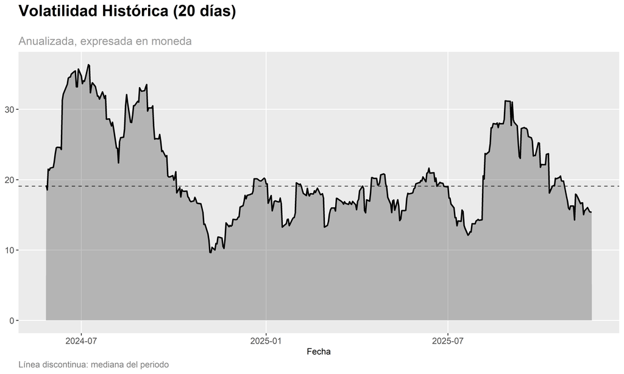

## Retorno y Riesgo

Métricas de Riesgo y Performance

| Métrica | Valor |
| --- | --- |
| **Value at Risk** |  |
| VaR Diario (95%) - En dinero | ₡ 1.82 |
| VaR Diario (95%) - En % | 0.37 % |
| VaR Semanal (95%) - En dinero | ₡ 5.37 |
| VaR Semanal (95%) - En % | 1.08 % |
| VaR Anual (95%) - En dinero | ₡ 39.16 |
| VaR Anual (95%) - En % | 7.90 % |
| **Métricas de Volatilidad** |  |
| Máxima Pérdida Histórica (Max Drawdown) | 28.66 % |
| Volatilidad Actual (20d) | 3.10 % |
| Volatilidad Histórica (Anual) | 3.78 % |
| **Ratio de Performance** |  |
| Sharpe Ratio (aprox.) | -0.18 |

```
Fecha límite calculada: 2025-05-01
```

| Mes | Retorno Mensual |
| --- | --- |
| November 2025 | -0.49% |
| October 2025 | -0.42% |
| September 2025 | -0.86% |
| August 2025 | -0.56% |
| July 2025 | -0.01% |
| June 2025 | -0.24% |
| May 2025 | 0.28% |

# 📈 Análisis de Distribuciones

[figure not shown]

# 📊 Dashboard de Señales

Dashboard de Señales Técnicas

[output not shown]

#### 📝 Notas Metodológicas

- **Bandas de Normalidad:** Un valor fuera de las bandas de normalidad es un movimiento inusual en el respectivo corto, largo o mediano plazo
- **RSI:** Índice de Fuerza Relativa: compara caídas y subidas en los últimos 14 días para identificar si puede venir un cambio significativo
- **VaR/CVaR:** Value at Risk indica la cantidad que puedo llegar perder ante un evento poco usual
- **Volatilidad:** mide qué tanto ha variado el precio en los últimos 20 días y lo proyecta a lo que sería en un año
- **Tendencias:** Trayectoria más probable del Tipo de Cambio

Reporte generado automáticamente el 27 de November, 2025 a las 12:21 | © Equipo de Inteligencia de Negocios